# IODS course project

Pinja Mero

# Introduction to Open Data Science - Course Project

# About the project

```r
# This is a so-called "R chunk" where you can write R code.

date()
```

```
## [1] "Mon Dec 13 08:59:30 2021"
```

```r
print('Hello, everyone!')
```

```
## [1] "Hello, everyone!"
```

I found this course while looking up the MOOC pages, and the subtitle sounded interesting. I’m quite familiar with R what comes to basic statistics and data mining, but with GitHub and the overall idea of sharing data I’m a complete rookie. I’m aiming to being more comfortable in open data environments and sharing my code with others. I’m also trying to keep my R skills up, since all my other courses are done with Matlab and Python at the moment.

This is my GitHub repository: https://github.com/Pinjahainen/IODS-project

## Week 2: Regression and model validation

```r
learn <- read.table('data/learning2014.txt', sep ='', header = T)
```

```r
# switch gender from F/M to 1/2
learn$gender[learn$gender == 'F'] <- 1
learn$gender[learn$gender == 'M'] <- 2
learn$gender <- as.integer(learn$gender)

str(learn)
```

```
## 'data.frame':    166 obs. of  7 variables:
##  $ gender  : int  1 2 1 2 2 1 2 1 2 1 ...
##  $ age     : int  53 55 49 53 49 38 50 37 37 42 ...
##  $ attitude: num  3.7 3.1 2.5 3.5 3.7 3.8 3.5 2.9 3.8 2.1 ...
##  $ deep    : num  3.58 2.92 3.5 3.5 3.67 ...
##  $ stra    : num  3.38 2.75 3.62 3.12 3.62 ...
##  $ surf    : num  2.58 3.17 2.25 2.25 2.83 ...
##  $ points  : int  25 12 24 10 22 21 21 31 24 26 ...
```

The learn dataframe includes 166 observations and 7 variables. In addition to gender and age, we have scoring points and some other variables which are summary variables from learning 2014 -questionnary, which are defining the strength of different learning methods of different students: Deep approach (deep), Surface approach (surf) and strategic approach (stra). The variable attitude is a sum variable which represents the overall attitude to statistics.

The aim of this analysis is to see if any of the variables are explaining the point scores of the students. To do this, we need to figure out the distributions of the variables.

To see the statistics of the variables, the histograms of the answers are plotted and their distributions are plotted on top of the histograms.

Over 2/3 of the answers are from female students. None of the variables are following the normal distribution well enough, but especially the points variable is problematic: it’s not normal enough for reliable linear modelling, but it’s definitely not a binary variable or following any other generalized linear model family. To keep things simple, the gaussian linear model is applied and the fact that points variable isn’t normal enough is included in the interpretation.

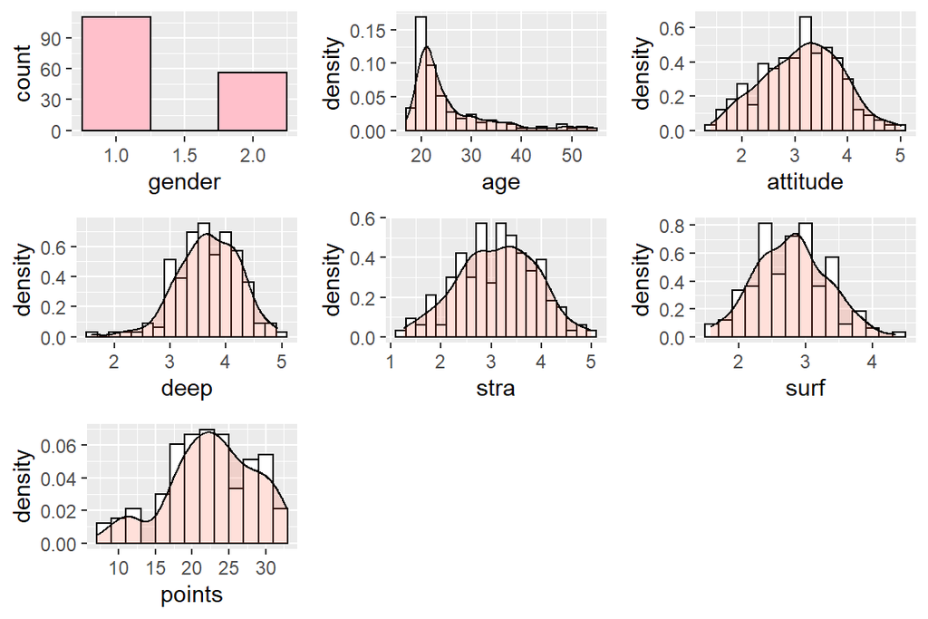

```r
library(ggplot2)
library(cowplot)

p1 <- ggplot(learn, aes(x = gender)) +
  geom_histogram(colour="black", fill="pink", binwidth = 0.5)
p2 <- ggplot(learn, aes(x = age)) +
  geom_histogram(aes(y=..density..), colour="black", fill="white", binwidth = 2) +
  geom_density(alpha=.2, fill="#FF6644")
p3 <- ggplot(learn, aes(x = attitude)) +
  geom_histogram(aes(y=..density..), colour="black", fill="white", binwidth = 0.2) +
  geom_density(alpha=.2, fill="#FF6644")
p4 <- ggplot(learn, aes(x = deep)) +
  geom_histogram(aes(y=..density..), colour="black", fill="white", binwidth = 0.2) +
  geom_density(alpha=.2, fill="#FF6644")
p5 <- ggplot(learn, aes(x = stra)) +
  geom_histogram(aes(y=..density..), colour="black", fill="white", binwidth = 0.2) +
  geom_density(alpha=.2, fill="#FF6644")
p6 <- ggplot(learn, aes(x = surf)) +
  geom_histogram(aes(y=..density..), colour="black", fill="white", binwidth = 0.2) +
  geom_density(alpha=.2, fill="#FF6644")
p7 <- ggplot(learn, aes(x = points)) +
  geom_histogram(aes(y=..density..), colour="black", fill="white", binwidth = 2) +
  geom_density(alpha=.2, fill="#FF6644")
plot_grid(p1, p2, p3, p4, p5, p6, p7)
```

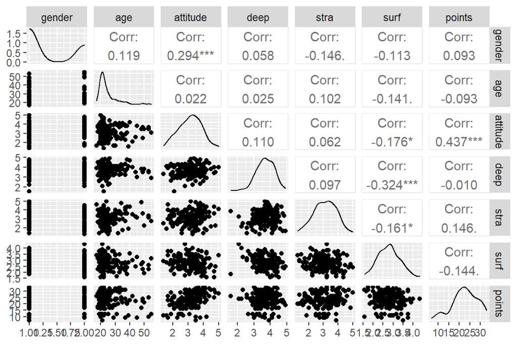

```r
library(GGally)
ggpairs(learn)
```

To select the three variables I cross-plot all of the variables. Correlations between points and attitude seems fine, but the rest of the variables doesn’t show any signs of correlation. The distribution of the variables seems not perfectly suitable for linear modelling, which needs to be considered while interpreting the results.

According to this analysis, there might be some multicollinearity present: attitude and gender correlates strongly, as are deep and surf. These effects need to be considered during the regression analysis.

The visual analysis can be confirmed by selecting all the variables to the model:

```r
lm1 <- lm(points~gender+age+attitude+deep+stra+surf, data=learn)

summary(lm1)
```

```
##
## Call:
## lm(formula = points ~ gender + age + attitude + deep + stra +
##     surf, data = learn)
##
## Residuals:
##      Min       1Q   Median       3Q      Max
## -17.4506  -3.2479   0.3879   3.5243  11.4820
##
## Coefficients:
##             Estimate Std. Error t value Pr(>|t|)
## (Intercept) 18.36105    5.34402   3.436 0.000754 ***
## gender      -0.05858    0.92985  -0.063 0.949845
## age         -0.09607    0.05396  -1.780 0.076929 .
## attitude     3.44300    0.59776   5.760 4.24e-08 ***
## deep        -1.04279    0.78438  -1.329 0.185606
## stra         0.95871    0.55150   1.738 0.084083 .
## surf        -1.10891    0.84467  -1.313 0.191132
## ---
## Signif. codes:  0 '***' 0.001 '**' 0.01 '*' 0.05 '.' 0.1 ' ' 1
##
## Residual standard error: 5.265 on 159 degrees of freedom
## Multiple R-squared:  0.2312, Adjusted R-squared:  0.2021
## F-statistic: 7.967 on 6 and 159 DF,  p-value: 1.599e-07
```

Based on both visual and linear analysis, the three variables selected are attitude, stra and age. The attitude and stra are following normal distribution better (but far from perfect) than age, which seems to follow maybe inverse chi-squared or gamma distribution.

```r
lm2 <- lm(points~age+attitude+stra, data=learn)

summary(lm2)
```

```
##
## Call:
## lm(formula = points ~ age + attitude + stra, data = learn)
##
## Residuals:
##      Min       1Q   Median       3Q      Max
## -18.1149  -3.2003   0.3303   3.4129  10.7599
##
## Coefficients:
##             Estimate Std. Error t value Pr(>|t|)
## (Intercept) 10.89543    2.64834   4.114 6.17e-05 ***
## age         -0.08822    0.05302  -1.664   0.0981 .
## attitude     3.48077    0.56220   6.191 4.72e-09 ***
## stra         1.00371    0.53434   1.878   0.0621 .
## ---
## Signif. codes:  0 '***' 0.001 '**' 0.01 '*' 0.05 '.' 0.1 ' ' 1
##
## Residual standard error: 5.26 on 162 degrees of freedom
## Multiple R-squared:  0.2182, Adjusted R-squared:  0.2037
## F-statistic: 15.07 on 3 and 162 DF,  p-value: 1.07e-08
```

```r
shapiro.test(lm2[['residuals']]) # check normality of the residuals
```

```
##
##  Shapiro-Wilk normality test
##
## data:  lm2[["residuals"]]
## W = 0.97757, p-value = 0.008555
```

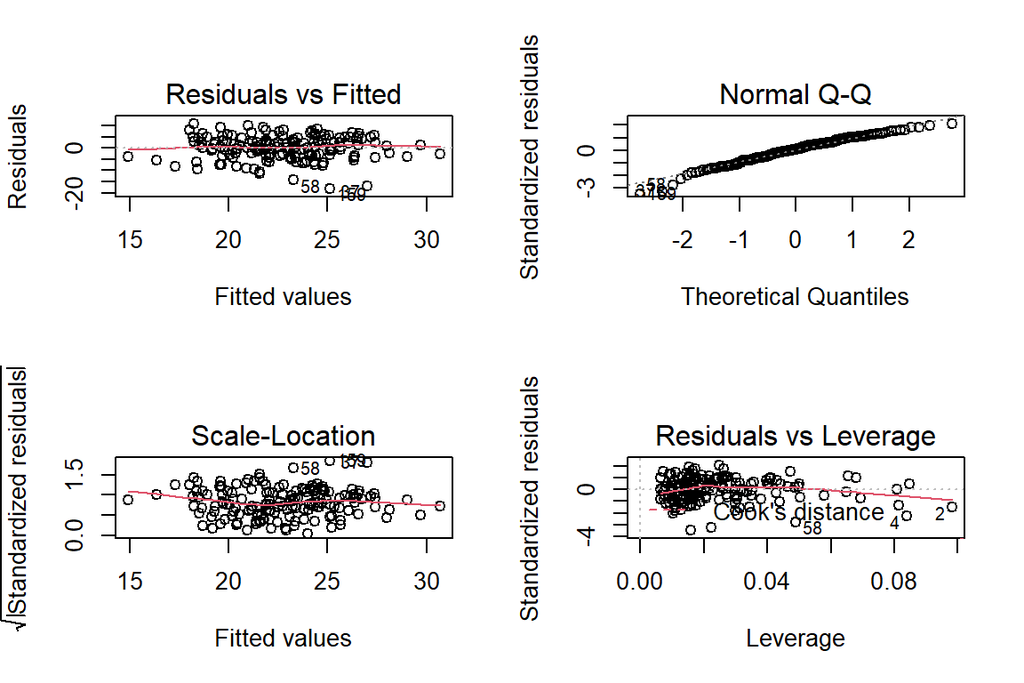

```r
par(mfrow=c(2,2))
plot(lm2)
```

```r
lm3 <- lm(points~attitude+stra, data=learn)
summary(lm3)
```

```
##
## Call:
## lm(formula = points ~ attitude + stra, data = learn)
##
## Residuals:
##      Min       1Q   Median       3Q      Max
## -17.6436  -3.3113   0.5575   3.7928  10.9295
##
## Coefficients:
##             Estimate Std. Error t value Pr(>|t|)
## (Intercept)   8.9729     2.3959   3.745  0.00025 ***
## attitude      3.4658     0.5652   6.132 6.31e-09 ***
## stra          0.9137     0.5345   1.709  0.08927 .
## ---
## Signif. codes:  0 '***' 0.001 '**' 0.01 '*' 0.05 '.' 0.1 ' ' 1
##
## Residual standard error: 5.289 on 163 degrees of freedom
## Multiple R-squared:  0.2048, Adjusted R-squared:  0.1951
## F-statistic: 20.99 on 2 and 163 DF,  p-value: 7.734e-09
```

```r
shapiro.test(lm3[['residuals']]) # check normality of the residuals
```

```
##
##  Shapiro-Wilk normality test
##
## data:  lm3[["residuals"]]
## W = 0.972, p-value = 0.001923
```

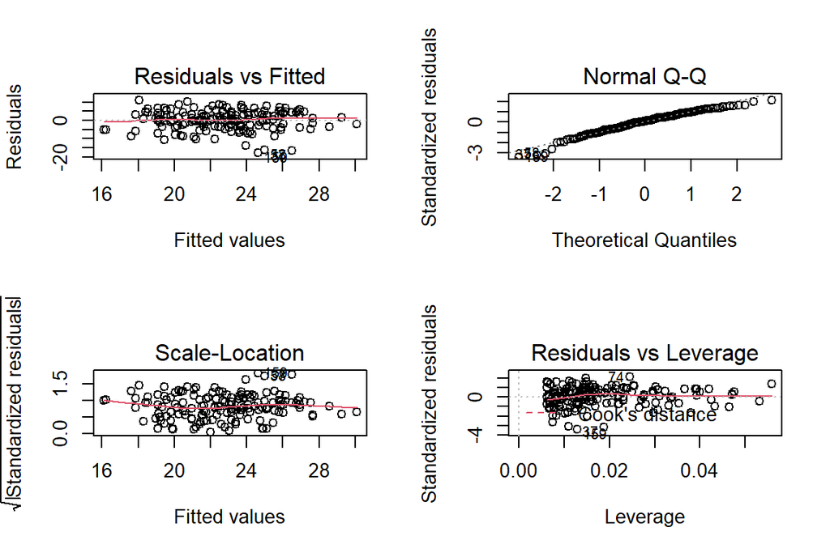

```r
par(mfrow=c(2,2))
plot(lm3)
```

```r
lm4 <- lm(points~attitude, data=learn)

summary(lm4)
```

```
##
## Call:
## lm(formula = points ~ attitude, data = learn)
##
## Residuals:
##      Min       1Q   Median       3Q      Max
## -16.9763  -3.2119   0.4339   4.1534  10.6645
##
## Coefficients:
##             Estimate Std. Error t value Pr(>|t|)
## (Intercept)  11.6372     1.8303   6.358 1.95e-09 ***
## attitude      3.5255     0.5674   6.214 4.12e-09 ***
## ---
## Signif. codes:  0 '***' 0.001 '**' 0.01 '*' 0.05 '.' 0.1 ' ' 1
##
## Residual standard error: 5.32 on 164 degrees of freedom
## Multiple R-squared:  0.1906, Adjusted R-squared:  0.1856
## F-statistic: 38.61 on 1 and 164 DF,  p-value: 4.119e-09
```

```r
shapiro.test(lm4[['residuals']]) # check normality of the residuals
```

```
##
##  Shapiro-Wilk normality test
##
## data:  lm4[["residuals"]]
## W = 0.97394, p-value = 0.003195
```

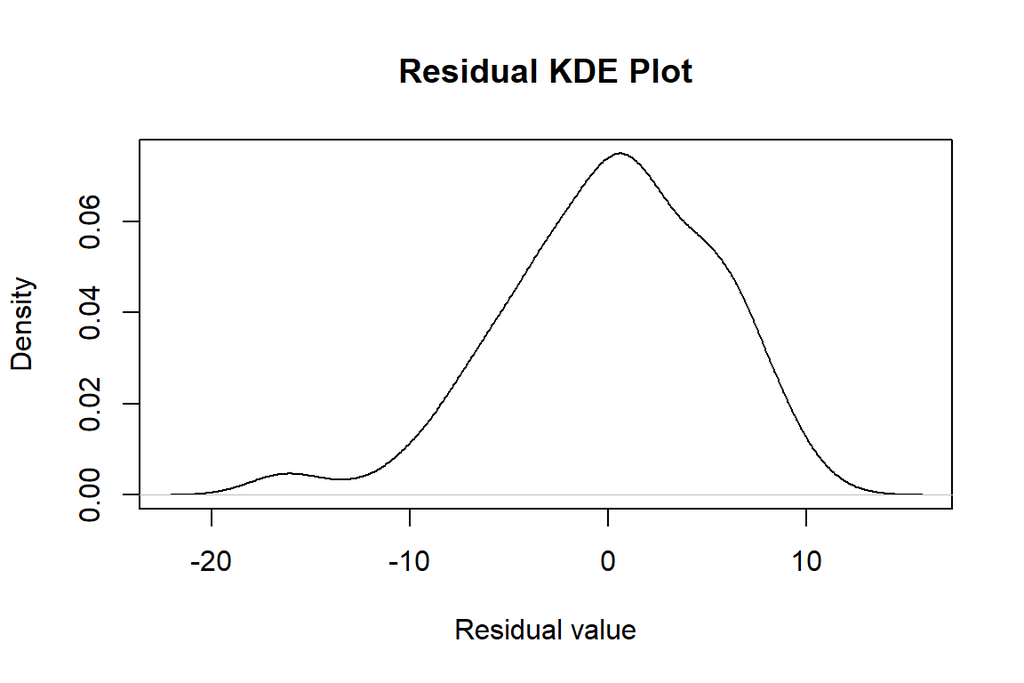

```r
d<-density(lm4[['residuals']])
plot(d,main='Residual KDE Plot',xlab='Residual value')
```

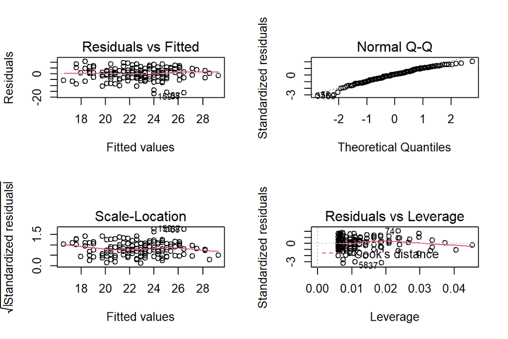

```r
par(mfrow=c(2,2))
plot(lm4)
```

Attitude towards statistics, however, is quite strongly explaining test scores, which makes sense: if one is afraid of the subject at hand, the studying isn’t effective. On the other hand, if student is very interested, the studying is easier and often more effective.

## 2

```r
library(openxlsx)
alc <- read.xlsx('data/pormath.xlsx')
ls(alc)
```

```
##  [1] "absences"   "absences.m" "absences.p" "activities" "address"
##  [6] "age"        "alc_use"    "cid"        "Dalc"       "failures"
## [11] "failures.m" "failures.p" "famrel"     "famsize"    "famsup"
## [16] "Fedu"       "Fjob"       "freetime"   "G1"         "G1.m"
## [21] "G1.p"       "G2"         "G2.m"       "G2.p"       "G3"
## [26] "G3.m"       "G3.p"       "goout"      "guardian"   "health"
## [31] "high_use"   "higher"     "id.m"       "id.p"       "internet"
## [36] "Medu"       "Mjob"       "n"          "nursery"    "paid"
## [41] "paid.m"     "paid.p"     "Pstatus"    "reason"     "romantic"
## [46] "school"     "schoolsup"  "sex"        "studytime"  "traveltime"
## [51] "Walc"
```

The data includes two studies with 51 variables icluding identification information, variables describing social environment and information of alchohol use.

## 3.

Tha aim of the study is to find variables connected to high alcohol consumption. From the 51 variables above. First the high-use variable need to be transformed as numeric variable:

```r
alc$high_use[alc$high_use == FALSE] <- 0
alc$high_use[alc$high_use == TRUE] <- 1
alc$high_use <- as.integer(alc$high_use)
```

The interesting variables of my choise are jops of the parents, studytime and family relations and support. The hypothesis here is that high alcohol consumption is related to the socioeconomic status of the family and the status and interest to school are inherited. There might be several co-effects in this datasets, which makes it difficult to determine the causal effect.

## 4.

```r
alc$famsup[alc$famsup == 'yes'] <- 1
alc$famsup[alc$famsup == 'no'] <- 0
alc$famsup <- as.integer(alc$famsup)
```

```r
table(alc$high_use, alc$famsup)
```

```
##
##       0   1
##   0  94 165
##   1  45  66
```

```r
table(alc$high_use, alc$Medu)
```

```
##
##      0  1  2  3  4
##   0  1 31 78 57 92
##   1  2 18 18 36 37
```

```r
table(alc$high_use, alc$Fedu)
```

```
##
##      0  1  2  3  4
##   0  2 49 75 70 63
##   1  0 24 30 27 30
```

```r
table(alc$high_use, alc$studytime)
```

```
##
##       1   2   3   4
##   0  56 128  52  23
##   1  42  57   8   4
```

```r
table(alc$high_use, alc$famrel)
```

```
##
##       1   2   3   4   5
##   0   6   9  39 128  77
##   1   2   9  25  52  23
```

according to cross-table, studytime and family relations are connected to high alcohol consumption, the rest of the variables not so much.

## 5.

```r
logit1 <- glm(high_use ~ Medu+Fedu+studytime+famrel+famsup, data=alc, family = 'binomial')
summary(logit1)
```

```
##
## Call:
## glm(formula = high_use ~ Medu + Fedu + studytime + famrel + famsup,
##     family = "binomial", data = alc)
##
## Deviance Residuals:
##     Min       1Q   Median       3Q      Max
## -1.4216  -0.8327  -0.7180   1.2973   2.1333
##
## Coefficients:
##             Estimate Std. Error z value Pr(>|z|)
## (Intercept)  1.36683    0.65017   2.102   0.0355 *
## Medu         0.01058    0.14102   0.075   0.9402
## Fedu         0.01828    0.14231   0.128   0.8978
## studytime   -0.61043    0.15657  -3.899 9.67e-05 ***
## famrel      -0.27611    0.12561  -2.198   0.0279 *
## famsup      -0.03781    0.24696  -0.153   0.8783
## ---
## Signif. codes:  0 '***' 0.001 '**' 0.01 '*' 0.05 '.' 0.1 ' ' 1
##
## (Dispersion parameter for binomial family taken to be 1)
##
##     Null deviance: 452.04  on 369  degrees of freedom
## Residual deviance: 428.95  on 364  degrees of freedom
## AIC: 440.95
##
## Number of Fisher Scoring iterations: 4
```

It seems that mother’s or father’s education level or family support doesn’t affect the alcohol consumption. In the other hand, family relations has effect on low significance, but studytime is clearly related to high alcohol consumption. This was expected, but the causality mechanism isn’t clear.

```r
logit2 <- glm(high_use ~ studytime+famrel, data=alc, family = 'binomial')
summary(logit2)
```

```
##
## Call:
## glm(formula = high_use ~ studytime + famrel, family = "binomial",
##     data = alc)
##
## Deviance Residuals:
##     Min       1Q   Median       3Q      Max
## -1.4109  -0.8242  -0.7221   1.3040   2.1177
##
## Coefficients:
##             Estimate Std. Error z value Pr(>|z|)
## (Intercept)   1.4219     0.5764   2.467   0.0136 *
## studytime    -0.6123     0.1542  -3.970 7.18e-05 ***
## famrel       -0.2756     0.1257  -2.193   0.0283 *
## ---
## Signif. codes:  0 '***' 0.001 '**' 0.01 '*' 0.05 '.' 0.1 ' ' 1
##
## (Dispersion parameter for binomial family taken to be 1)
##
##     Null deviance: 452.04  on 369  degrees of freedom
## Residual deviance: 429.02  on 367  degrees of freedom
## AIC: 435.02
##
## Number of Fisher Scoring iterations: 4
```

```r
print(c('Odds ratios: ', exp(coef(logit2))))
```

```
##                             (Intercept)           studytime              famrel
##     "Odds ratios: "   "4.1448217568963" "0.542075820198362" "0.759116543726991"
```

According to the odds ratios, increasing study time decreases odds of high alcohol consumption to half. increasing value family relations affect is smaller, decreasing the odds to only 3/4.

## Chapter 4: Clustering and classification

### Analysis exercise

#### 2.

Checking if I allready have a MASS package:

```r
a<-installed.packages()
packages<-a[,1]
is.element("MASS", packages)
```

```
## [1] TRUE
```

MASS Package exists, load the library and observe the dataset:

```r
library(MASS)
str(Boston)
```

```
## 'data.frame':    506 obs. of  14 variables:
##  $ crim   : num  0.00632 0.02731 0.02729 0.03237 0.06905 ...
##  $ zn     : num  18 0 0 0 0 0 12.5 12.5 12.5 12.5 ...
##  $ indus  : num  2.31 7.07 7.07 2.18 2.18 2.18 7.87 7.87 7.87 7.87 ...
##  $ chas   : int  0 0 0 0 0 0 0 0 0 0 ...
##  $ nox    : num  0.538 0.469 0.469 0.458 0.458 0.458 0.524 0.524 0.524 0.524 ...
##  $ rm     : num  6.58 6.42 7.18 7 7.15 ...
##  $ age    : num  65.2 78.9 61.1 45.8 54.2 58.7 66.6 96.1 100 85.9 ...
##  $ dis    : num  4.09 4.97 4.97 6.06 6.06 ...
##  $ rad    : int  1 2 2 3 3 3 5 5 5 5 ...
##  $ tax    : num  296 242 242 222 222 222 311 311 311 311 ...
##  $ ptratio: num  15.3 17.8 17.8 18.7 18.7 18.7 15.2 15.2 15.2 15.2 ...
##  $ black  : num  397 397 393 395 397 ...
##  $ lstat  : num  4.98 9.14 4.03 2.94 5.33 ...
##  $ medv   : num  24 21.6 34.7 33.4 36.2 28.7 22.9 27.1 16.5 18.9 ...
```

```r
d <- dim(Boston)
d
```

```
## [1] 506  14
```

The dataset contains 14 variables and 506 observations. It describes the socio-economic conditions in Boston by housing values of suburbs.

#### 3.

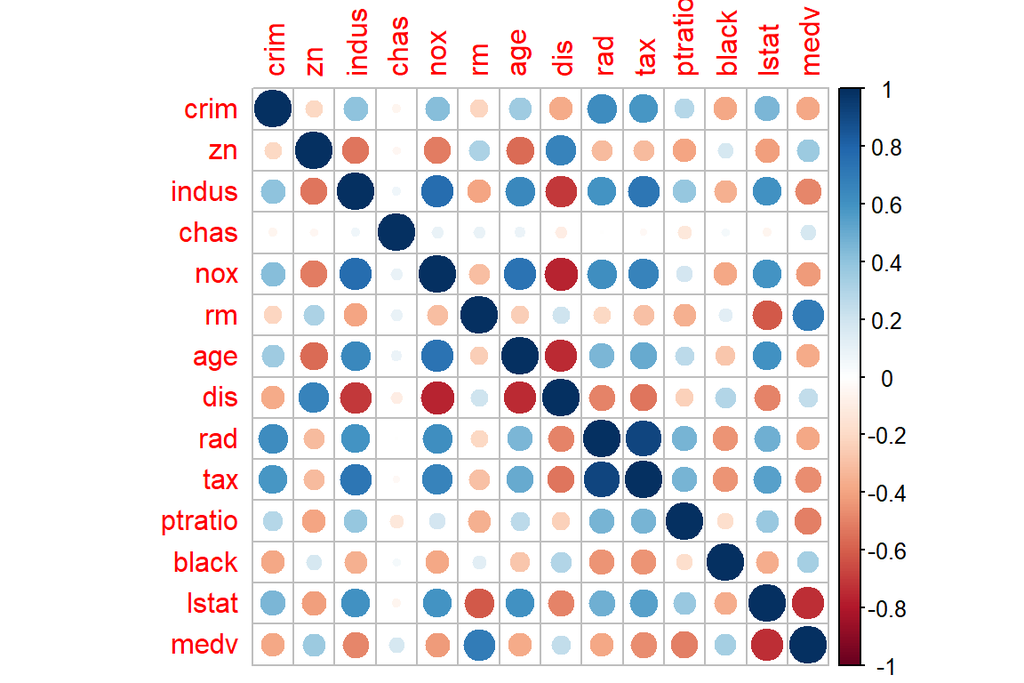

```r
library(corrplot)
cormat <- cor(Boston);
corrplot(cormat, method = 'circle')
```

Some correlation can be observed between the variables.

Summaries:

```r
B_sum <- setNames(data.frame(matrix(ncol = 6, nrow = 0)),
              c('Min', '1st Qu', 'Median', 'Mean', '3rd Qu', 'Max'))     #set the empty data frame
for(i in 1:d[2]) {                              # For-loop to create the 14 summary rows
  new <- round(summary(Boston[,i]), digits = 2)   # Create new summary row
  B_sum[nrow(B_sum) + 1, ] <- new                         # Append new row
}
row.names(B_sum) <- colnames(Boston)                  # Set row names
B_sum
```

```
##            Min 1st Qu Median   Mean 3rd Qu    Max
## crim      0.01   0.08   0.26   3.61   3.68  88.98
## zn        0.00   0.00   0.00  11.36  12.50 100.00
## indus     0.46   5.19   9.69  11.14  18.10  27.74
## chas      0.00   0.00   0.00   0.07   0.00   1.00
## nox       0.38   0.45   0.54   0.55   0.62   0.87
## rm        3.56   5.89   6.21   6.28   6.62   8.78
## age       2.90  45.02  77.50  68.57  94.07 100.00
## dis       1.13   2.10   3.21   3.80   5.19  12.13
## rad       1.00   4.00   5.00   9.55  24.00  24.00
## tax     187.00 279.00 330.00 408.24 666.00 711.00
## ptratio  12.60  17.40  19.05  18.46  20.20  22.00
## black     0.32 375.38 391.44 356.67 396.22 396.90
## lstat     1.73   6.95  11.36  12.65  16.96  37.97
## medv      5.00  17.02  21.20  22.53  25.00  50.00
```

#### 4.

Summary of the variables (in data frame to look a bit nicer)

```r
B_scaled <- data.frame(scale(Boston))

Bsc_sum <- setNames(data.frame(matrix(ncol = 6, nrow = 0)),
              c('Min', '1st Qu', 'Median', 'Mean', '3rd Qu', 'Max'))     #set the empty data frame
for(i in 1:d[2]) {                              # For-loop to create the 14 summary rows
  new <- round(summary(B_scaled[,i]), digits = 2)   # Create new summary row
  Bsc_sum[nrow(Bsc_sum) + 1, ] <- new                         # Append new row
}
row.names(Bsc_sum) <- colnames(Boston)                  # Set row names
Bsc_sum
```

```
##           Min 1st Qu Median Mean 3rd Qu  Max
## crim    -0.42  -0.41  -0.39    0   0.01 9.92
## zn      -0.49  -0.49  -0.49    0   0.05 3.80
## indus   -1.56  -0.87  -0.21    0   1.01 2.42
## chas    -0.27  -0.27  -0.27    0  -0.27 3.66
## nox     -1.46  -0.91  -0.14    0   0.60 2.73
## rm      -3.88  -0.57  -0.11    0   0.48 3.55
## age     -2.33  -0.84   0.32    0   0.91 1.12
## dis     -1.27  -0.80  -0.28    0   0.66 3.96
## rad     -0.98  -0.64  -0.52    0   1.66 1.66
## tax     -1.31  -0.77  -0.46    0   1.53 1.80
## ptratio -2.70  -0.49   0.27    0   0.81 1.64
## black   -3.90   0.20   0.38    0   0.43 0.44
## lstat   -1.53  -0.80  -0.18    0   0.60 3.55
## medv    -1.91  -0.60  -0.14    0   0.27 2.99
```

Catergorical criminal rate

```r
B_scaled$c_crim[B_scaled$crim <= -0.41] <- 1
B_scaled$c_crim[B_scaled$crim > -0.41 & B_scaled$crim <= 0] <- 2
B_scaled$c_crim[B_scaled$crim > 0 & B_scaled$crim <= 0.01] <- 3
B_scaled$c_crim[B_scaled$crim > 0.01] <- 4
B_scaled$crim <- NULL
```

Divide the data to train and test set:

```r
library(dplyr)
B_train <- B_scaled %>% sample_frac(.8)
names <- row.names(B_train)
B_test <- B_scaled[!row.names(B_scaled) %in% names,]
```

LDA

```r
m1 <- lda(c_crim ~., data = B_train) #LDA witc clustered crime rate as target
summary(m1)
```

```
##         Length Class  Mode
## prior    4     -none- numeric
## counts   4     -none- numeric
## means   52     -none- numeric
## scaling 39     -none- numeric
## lev      4     -none- character
## svd      3     -none- numeric
## N        1     -none- numeric
## call     3     -none- call
## terms    3     terms  call
## xlevels  0     -none- list
```

#### 5.

The LDA plot didn’t work as expected, no time to fix things:

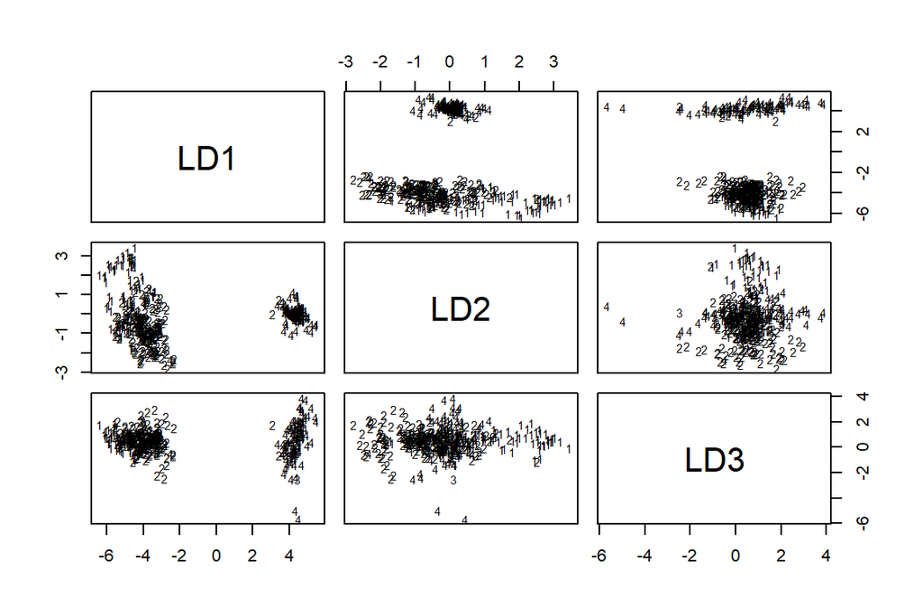

```r
plot(m1, fac=m1$fac)
```

Tested the function from the course page nonetheless:

```r
library(RColorBrewer)
col <- brewer.pal(8, 'Set1')
palette(col)

lda.arrows <- function(x, myscale = 1, arrow_heads = 0.2, color = "orange", tex = 2, choices = c(1,2), lwd= 2){
  heads <- coef(x)
  arrows(x0 = 0, y0 = 0,
         x1 = myscale * heads[,choices[1]],
         y1 = myscale * heads[,choices[2]], col=color, length = arrow_heads, lwd=2)
  text(myscale * heads[,choices], labels = row.names(heads),
       cex = tex, col=color, pos=3, lwd=2.5)
}
par(cex.label=2, cex.lab=2, cex =1.5, mar=c(5,6,3,3))
```

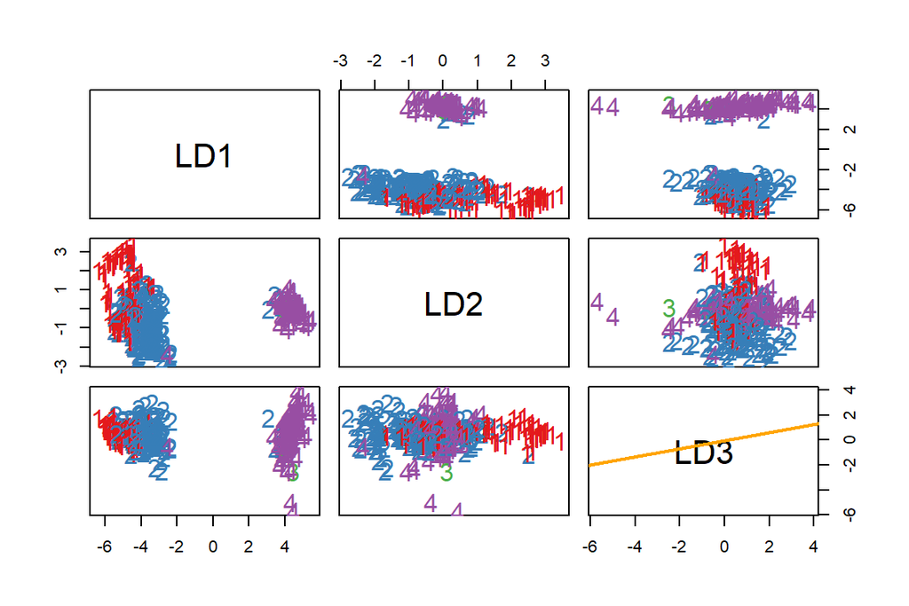

```r
plot(m1, col=as.numeric(B_train$c_crim),  cex =1.5)
lda.arrows(m1)
```

#### 6. Removing the classes from the test set and predicting the classes (didn’t finish)

```r
B_test_class <- B_train
B_test$c_crim <- NULL

new_class <- predict(m1, B_test)
```

#### 7.

```r
Boston_scaled <- scale(Boston)

library(stats)
K4 <- kmeans(Boston_scaled, 4, iter.max = 10, nstart = 1)
```

```r
human <- read.csv('data/human.txt')
human
```

[output not shown]

[output cut: 311 more lines]

```r
d <- dim(human)

summary(human)
```

```
##       X                Edu2.FM          Labo.FM          Edu.Exp
##  Length:162         Min.   :0.1717   Min.   :0.1857   Min.   : 5.40
##  Class :character   1st Qu.:0.7254   1st Qu.:0.5981   1st Qu.:11.22
##  Mode  :character   Median :0.9327   Median :0.7514   Median :13.45
##                     Mean   :0.8499   Mean   :0.7034   Mean   :13.13
##                     3rd Qu.:0.9958   3rd Qu.:0.8525   3rd Qu.:15.20
##                     Max.   :1.4967   Max.   :1.0380   Max.   :20.20
##     Life.Exp          GNI             Mat.Mor         Ado.Birth
##  Min.   :49.00   Min.   :  1.123   Min.   :   1.0   Min.   :  0.60
##  1st Qu.:66.42   1st Qu.:  5.370   1st Qu.:  13.0   1st Qu.: 13.57
##  Median :74.00   Median : 12.922   Median :  55.0   Median : 35.00
##  Mean   :71.58   Mean   : 44.965   Mean   : 150.3   Mean   : 47.35
##  3rd Qu.:76.95   3rd Qu.: 26.029   3rd Qu.: 190.0   3rd Qu.: 71.78
##  Max.   :83.50   Max.   :908.000   Max.   :1100.0   Max.   :204.80
##     Parli.F
##  Min.   : 0.00
##  1st Qu.:12.50
##  Median :19.30
##  Mean   :20.88
##  3rd Qu.:27.55
##  Max.   :57.50
```

```r
bprs <- read.table('data/bprs_long.txt', sep =',', header = T)
rats <- read.table('data/rats_long.txt', sep =',', header = T)
bprs$treatment[bprs$treatment == 1] <- 'Treatment 1'
bprs$treatment[bprs$treatment == 2] <- 'Treatment 2'
bprs$treatment <- as.factor(bprs$treatment)
bprs$subject <- as.factor(bprs$subject)
bprs$week[bprs$week == 'week0'] <- 0
bprs$week[bprs$week == 'week1'] <- 1
bprs$week[bprs$week == 'week2'] <- 2
bprs$week[bprs$week == 'week3'] <- 3
bprs$week[bprs$week == 'week4'] <- 4
bprs$week[bprs$week == 'week5'] <- 5
bprs$week[bprs$week == 'week6'] <- 6
bprs$week[bprs$week == 'week7'] <- 7
bprs$week[bprs$week == 'week8'] <- 8
bprs$week <- as.numeric(bprs$week)
```

## 1. BPRS, chapter 8

The data set is a longitudal data covering 20 individuals through 8 weeks period. BPRS measurement is a psychiatric measurement covering behavioral observations defining mental health state of the patient. In time series analysis the same features are measured repeatedly over time using same test methods and the timing of the measurements is known. The long form enables us to perform the analysis using one variable effected by another, which enables us to take all of the time points into account in the analysis.

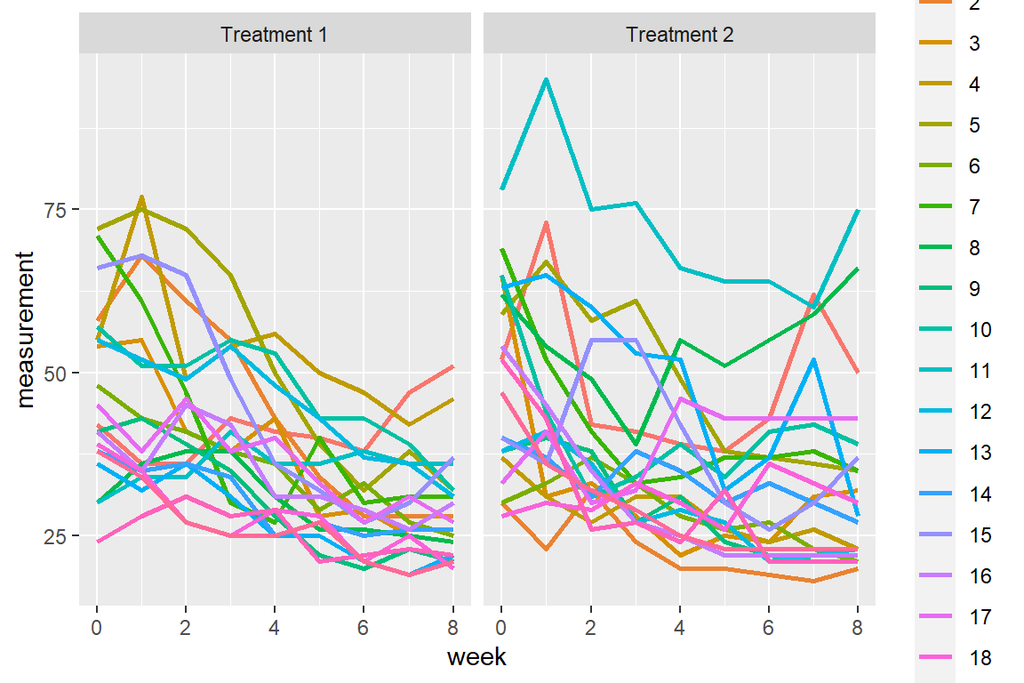

```r
library('ggplot2')

ggplot(bprs, aes(x = week, y = measurement, color = subject)) +
  facet_wrap(~ treatment) +
  geom_line(size = 1)
```

```r
  geom_point()
```

[output not shown]

```r
  labs(x = "week", y = "measurement")
```

[output not shown]

Plot 1 shows the development of bprs measurements of each subjects 1-20 throuhg time for treatments 1 and 2. It seems that treatment 1 could have more consistent effect on psychiatric rating scale.

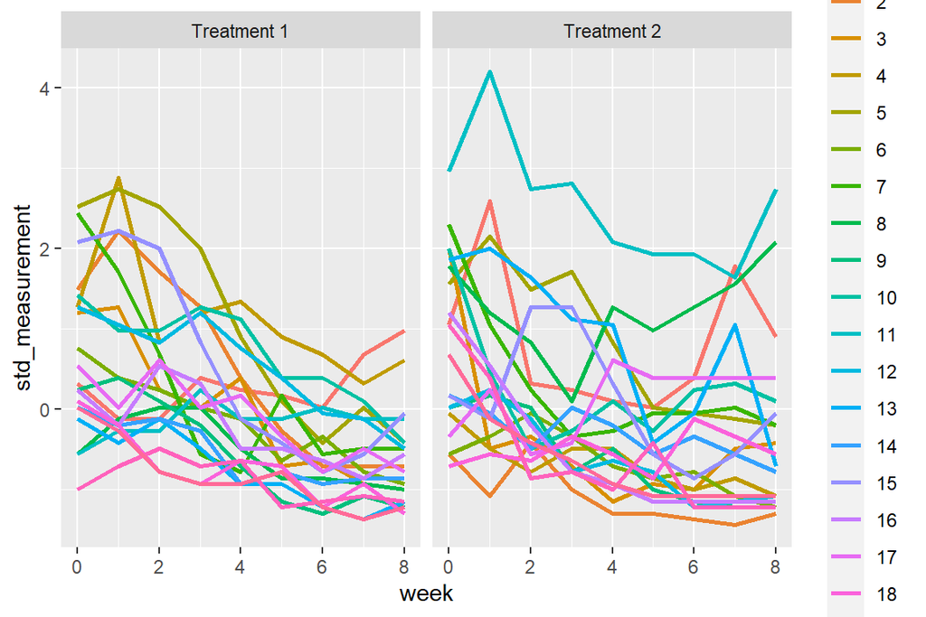

```r
bprs$std_measurement <- scale(bprs$measurement)
library('ggplot2')

ggplot(bprs, aes(x = week, y = std_measurement, color = subject)) +
  facet_wrap(~ treatment) +
  geom_line(size = 1)
```

```r
  geom_point()
```

[output not shown]

```r
  labs(x = "week", y = "measurement")
```

[output not shown]

```r
means <- c()
std <- c()
treatment <- c()
for(i in 1:9){
  means[i] <- mean(bprs$measurement[bprs$treatment == 'Treatment 1' & bprs$week == i-1])
  std[i] <- sd(bprs$measurement[bprs$treatment == 'Treatment 1' & bprs$week == i-1])
  treatment[i] <- 1
}

for(i in 10:18){
  means[i] <- mean(bprs$measurement[bprs$treatment == 'Treatment 2' & bprs$week == i-10])
  std[i] <- sd(bprs$measurement[bprs$treatment == 'Treatment 2' & bprs$week == i-10])
  treatment[i] <- 2
}

bprs_means <- data.frame(week = c(0:8, 0:8), mean_measure = means, std = std, Treatment = treatment)

bprs_means$Treatment <- factor(bprs_means$Treatment)
```

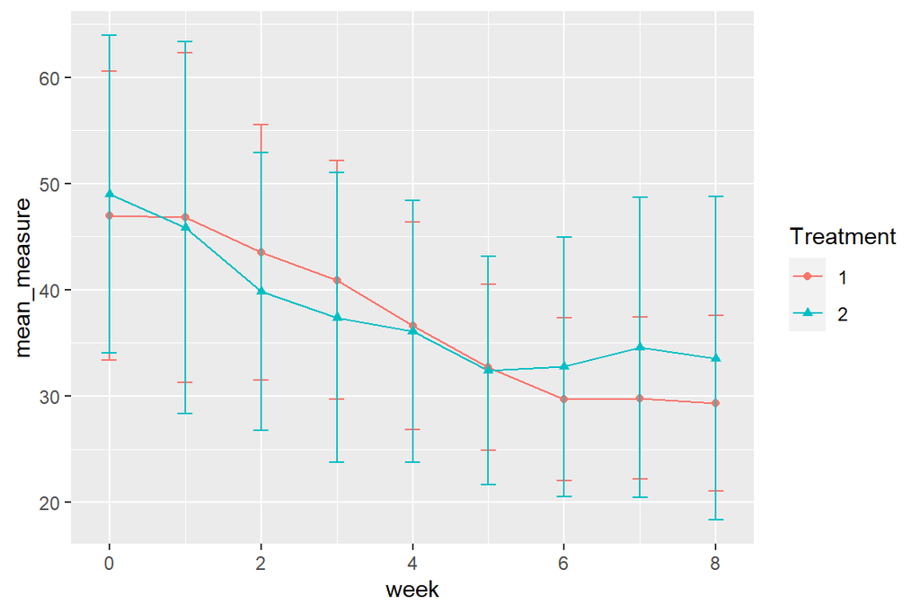

```r
ggplot(bprs_means, aes(x = week, y = mean_measure, color = Treatment)) +
  geom_line(aes(group = Treatment)) +
  geom_point(aes(shape = Treatment)) +
  geom_errorbar(aes(ymin = mean_measure - std, ymax = mean_measure + std), width = 0.2)
```

```r
  labs(x = "week", y = "measurement")
```

[output not shown]

The error bar visualization reveals that there’s no significant differences between treatments.

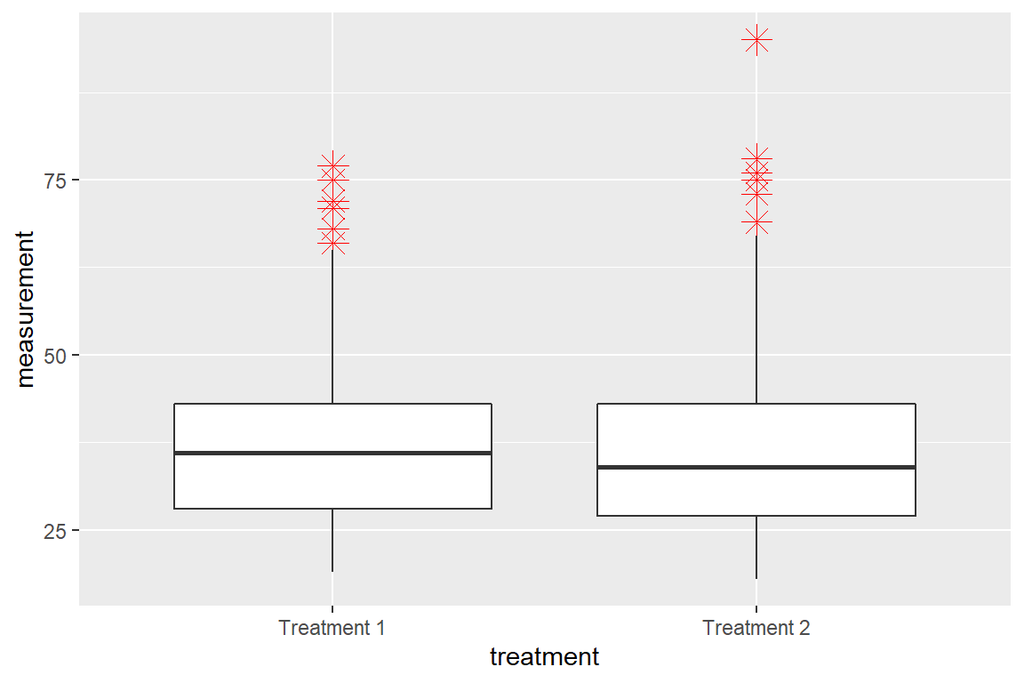

```r
ggplot(bprs, aes(x=treatment, y=measurement)) +
  geom_boxplot(outlier.colour="red", outlier.shape=8,
                outlier.size=4)
```

Next I want to test the changes in the bprs measurements at the beginning and at the end of the treatments. The null hypothesis according to the mean plot is that the means of the changes doesn’t differ from each other.

```r
cha1 <- bprs$measurement[bprs$week == 0 & bprs$treatment == 'Treatment 1'] - bprs$measurement[bprs$week == 8 & bprs$treatment == 'Treatment 1']
cha2 <- bprs$measurement[bprs$week == 0 & bprs$treatment == 'Treatment 2'] - bprs$measurement[bprs$week == 8 & bprs$treatment == 'Treatment 2']

changes <- data.frame(treatment = c(rep(1, 20), rep(2, 20)), change = c(cha1, cha2))

dim(changes)
```

```
## [1] 40  2
```

```r
t1 <- t.test(changes$change[changes$treatment == 1], changes$change[changes$treatment == 2])

t1
```

```
##
##  Welch Two Sample t-test
##
## data:  changes$change[changes$treatment == 1] and changes$change[changes$treatment == 2]
## t = 0.52093, df = 37.916, p-value = 0.6054
## alternative hypothesis: true difference in means is not equal to 0
## 95 percent confidence interval:
##  -6.494436 10.994436
## sample estimates:
## mean of x mean of y
##     17.70     15.45
```

There’s no evidence that the treatments would have different results. The null hypothesis is valid.

## 2. RATS, chapter 9

The next analysis is a longitudal study about 3 groups of rats and their growing rates over two months period with 11 time points.

```r
rats$time[rats$time == 'WD1'] <- 'WD01'
rats$time[rats$time == 'WD8'] <- 'WD08'
rats$Group <- as.factor(rats$Group)
```

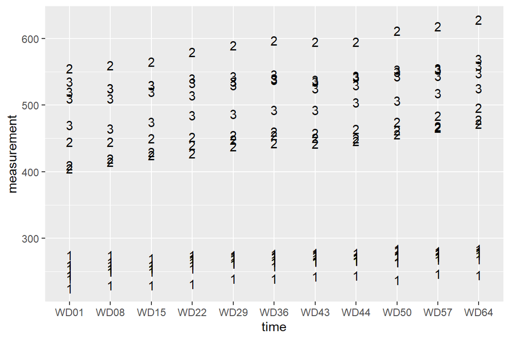

```r
ggplot(rats, aes(time, measurement)) + geom_text(aes(label = Group))
```

The long data isn’t independent, which can be seen in this plot. This must be taken into account while makind the regression analysis.

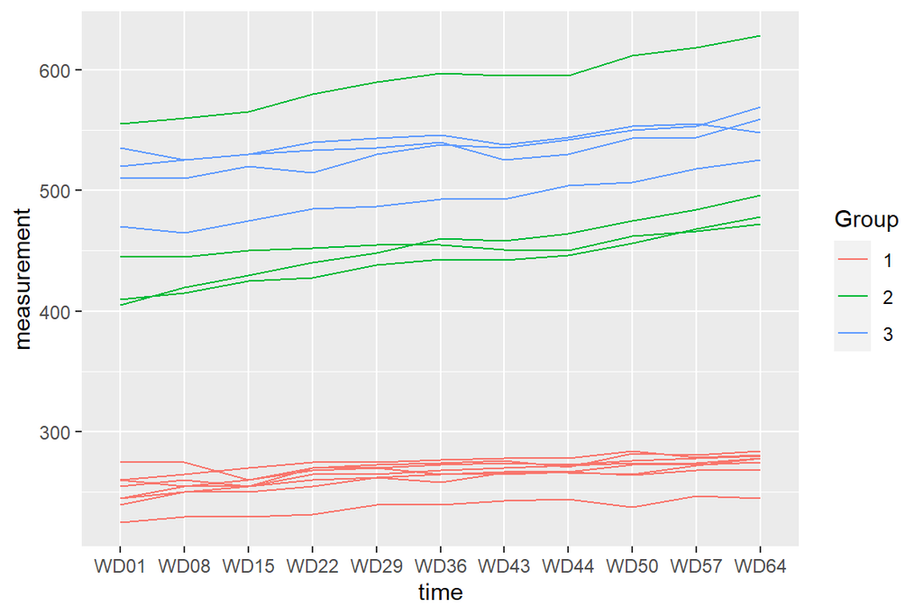

```r
ggplot(rats, aes(x = time, y = measurement, color = Group)) +
  geom_line(aes(group = ID))
```

```r
  geom_point()
```

[output not shown]

```r
  labs(x = "time", y = "weight")
```

[output not shown]

The plots shows that the rats from group 1 is much smaller than the other two groups and there’s not much of growing happening.

Making time variable ready for analysis:

```r
sub('WD', '', rats$time);
```

[output not shown]

```r
class(rats$time)
```

```
## [1] "character"
```

```r
rats$timen <- as.numeric(as.factor(rats$time));
class(rats$timen)
```

```
## [1] "numeric"
```

Fitting a mixed model with correlated random effects, Group as a random effect:

```r
library(lme4)
m1<-lmer(measurement~1+timen+(1+timen|Group), data=rats)
```

```
## boundary (singular) fit: see ?isSingular
```

```r
summary(m1)
```

```
## Linear mixed model fit by REML ['lmerMod']
## Formula: measurement ~ 1 + timen + (1 + timen | Group)
##    Data: rats
##
## REML criterion at convergence: 1748.1
##
## Scaled residuals:
##     Min      1Q  Median      3Q     Max
## -1.6529 -0.7174  0.0243  0.2813  3.5152
##
## Random effects:
##  Groups   Name        Variance  Std.Dev. Corr
##  Group    (Intercept) 17350.171 131.72
##           timen           2.341   1.53   1.00
##  Residual              1161.906  34.09
## Number of obs: 176, groups:  Group, 3
##
## Fixed effects:
##             Estimate Std. Error t value
## (Intercept)  400.516     76.252   5.253
## timen          4.032      1.200   3.359
##
## Correlation of Fixed Effects:
##       (Intr)
## timen 0.691
## optimizer (nloptwrap) convergence code: 0 (OK)
## boundary (singular) fit: see ?isSingular
```

```r
anova(m1)
```

```
## Analysis of Variance Table
##       npar Sum Sq Mean Sq F value
## timen    1  13110   13110  11.283
```

Making dummy variables for future regression analysis:

```r
rats$D1[rats$Group == 1] <- 0
rats$D2[rats$Group == 1] <- 0

rats$D1[rats$Group == 2] <- 1
rats$D2[rats$Group == 2] <- 0

rats$D1[rats$Group == 3] <- 1
rats$D2[rats$Group == 3] <- 1
```